# Metabarcoding Analysis

# Introduction

See slides on metabarcoding

# Setup

```r
library(ggplot2)
library(ape)
library(ggtree)
library(vegan)
```

## Data

Create a directory called `Data` inside of your working directory. Then downlod the zip file below and unzip it to your Data folder:

- OTU_files.zip

The folder should contain these files:

- OTU_table_QIIME1.txt
- SampleInfo.csv

# Background

These data are from a meta-analysis of plant microbiome studies using 16S metabarcodes. Each sample is a plant that was sequenced for 16S to identify the bacteria associated with it.

Let’s take a look at the data:

# Sample Info

This file contains information about the samples. It is essentially an index that links a specific sample code to the species that it was taken from.

```r
Samples<-read.csv("./Data/SampleInfo.csv")
```

# OTU Table

```r
OTU_table <- read.delim("./Data/OTU_table_QIIME1.txt", header=T, row.names="OTU_ID")
```

This is a simple table tab-delimited data table. Note that it is imported with the `read.delim()` function in R, which translates a tab character `\t` into columns. If we were to open it in a text file, the first four lines would look like this:

```
OTU_ID  SRR4267992  SRR4289215  SRR5211360  SRR5211361  SRR5439762  SRR5439772  SRR4267987  SRR4289218  SRR4734815  SRR4708713  SRR5051401  SRR5051407  SRR5051999  SRR5052001  SRR5052006  SRR5051567  SRR5052003  SRR5051415  SRR5051568  ERR632209   SRR4267988  SRR4289217  SRR2087833  SRR2087830  SRR2…
4479946 1.0 1.0 0.0 0.0 0.0 0.0 0.0 0.0 0.0 0.0 0.0 0.0 0.0 0.0 0.0 0.0 0.0 0.0 0.0 0.0 0.0 0.0 0.0 0.0 0.0 0.0 0.0 0.0 0.0 0.0 0.0 0.0 0.0 0.0 0.0 0.0 0.0 0.0 0.0 0.0 0.0 0.0 0.0 0.0 0.0 0.0 0.0 0.0 0.0 0.0 0.0 0.0 0.0 0.0 0.0 0.0 0.0 0.0 0.0 0.0 0.0 0.0 0.0 0.0 0.0 0.0 0.0 0.0 0.0 0.0 0.0 0.0 0.0 …
4386156 0.0 0.0 1.0 2.0 0.0 0.0 0.0 0.0 0.0 0.0 0.0 0.0 0.0 0.0 0.0 0.0 0.0 0.0 0.0 0.0 0.0 0.0 0.0 0.0 0.0 0.0 0.0 0.0 0.0 0.0 0.0 0.0 0.0 0.0 0.0 0.0 0.0 0.0 0.0 0.0 0.0 0.0 0.0 0.0 0.0 0.0 0.0 0.0 0.0 0.0 0.0 0.0 0.0 0.0 0.0 0.0 0.0 0.0 0.0 0.0 0.0 0.0 0.0 0.0 0.0 0.0 0.0 0.0 0.0 0.0 0.0 0.0 0.0 …
```

## Parsed table

Once parsed, the data are easier to understand:

|  | SRR4267992 | SRR4289215 | SRR5211360 | SRR5211361 | SRR5439762 | SRR5439772 | SRR4267987 | SRR4289218 | SRR4734815 | SRR4708713 | SRR5051401 | SRR5051407 | SRR5051999 | SRR5052001 | SRR5052006 | SRR5051567 | SRR5052003 | SRR5051415 | SRR5051568 | ERR632209 | SRR4267988 | SRR4289217 | SRR2087833 | SRR2087830 | SRR2087835 | ERR1745180 | ERR1745155 | ERR1745154 | ERR1745153 | … |
| --- | --- | --- | --- | --- | --- | --- | --- | --- | --- | --- | --- | --- | --- | --- | --- | --- | --- | --- | --- | --- | --- | --- | --- | --- | --- | --- | --- | --- | --- | --- |
| 432284 | 31 | 31 | 0 | 0 | 3 | 5 | 5 | 5 | 0 | 0 | 0 | 0 | 0 | 0 | 0 | 0 | 0 | 0 | 0 | 22 | 22 | 22 | 0 | 1 | 0 | 0 | 0 | 0 | 2 | … |
| 694558 | 0 | 0 | 91 | 108 | 0 | 0 | 0 | 0 | 0 | 0 | 0 | 0 | 0 | 0 | 0 | 0 | 0 | 0 | 0 | 0 | 0 | 0 | 0 | 1 | 17 | 1 | 0 | 0 | 0 | … |
| 543472 | 0 | 0 | 0 | 0 | 69 | 0 | 0 | 0 | 0 | 0 | 0 | 0 | 0 | 0 | 0 | 0 | 0 | 0 | 0 | 0 | 0 | 0 | 0 | 0 | 0 | 0 | 0 | 0 | 0 | … |
| 938794 | 0 | 0 | 22 | 0 | 0 | 0 | 7 | 7 | 0 | 0 | 0 | 1 | 0 | 0 | 0 | 1 | 0 | 0 | 0 | 0 | 0 | 0 | 1 | 0 | 2 | 0 | 0 | 0 | 0 | … |

Note that this is a 16.5MB file, so only a few lines are printed here. The first column contains the `OTU_ID` – this is a unique ID number assigned to a unique ‘Operational Taxonomic Unit’ or OTU. The term OTU is common for microbes like bacteria and fungi where species concepts don’t work so well. Since we are inferring taxonomy from a single gene, all sequences that share the same sequence are considered part of the same OTU.

The next columns start with `SRR`. These are the the individual samples that were sequenced. Each number in the `SRR` column corresponds to the number of sequences for the OTU that were present in that sample.

The last column is called `taxonomy` and contains the predicted taxonomic assignment for each OTU. Let’s remove these so that we aren’t mixing numeric and character data.

```r
OTU_data<-OTU_table[,-ncol(OTU_table)]
```

Let’s see how many OTUs and samples are in the dataset:

```r
dim(OTU_data)
```

```
## [1] 21201   177
```

> How many OTUs? How many samples?

## Remove errors

Let’s see how many total sequences are in this dataset:

```r
X<-rowSums(OTU_data)
sum(X)
```

```
## [1] 18080169
```

```r
Drop<-rowSums(OTU_data) < 2
sum(Drop)
```

```
## [1] 3956
```

This will allow us to drop almost 4,000 OTUs from the analysis.

```r
OTU_red<-OTU_data[!Drop,]
```

## Table transpose

To analyze the OTU table, we need to rearrange with the species across the top and sample sizes along the bottom. A simple way to do this is with the transpose function `t()`. Since it’s a big file, let’s do it only on the first 3 rows and columns to see what happens:

```r
OTU_red[1:3,1:3]
```

```
##         SRR4267992 SRR4289215 SRR5211360
## 4479946          1          1          0
## 4386156          0          0          1
## 4479944          0          0          0
```

```r
t(OTU_red[1:3,1:3])
```

```
##            4479946 4386156 4479944
## SRR4267992       1       0       0
## SRR4289215       1       0       0
## SRR5211360       0       1       0
```

That looks good, so let’s do it for the whole dataset:

```r
OTUs<-as.data.frame(t(OTU_red))
```

# Analysis

Now that we have samples as rows and OTUs as columns, how can we compare the samples?

> Hint: How did we compare dragons with different traits?

(see the Dragon Phylogeny tutorial)

In an analogous fashion, we can calculate pairwise distances among our samples to create a distance matrix.

## Binary Distance matrix

We can change our `OTUs` dataframe into binary data by changing the read counts in each square to 1 or 0. Of course, we lose information of the relative number of sequences for each OTU, so we’ll look how to analyze that data later.

Transform to 1 if # reads >=1 and 0 otherwise. We could use a nested loop through each row and each column. You CAN do IT this WAY, but it may take a long time, so you might want to skip this code, but take some time to look at it carefully and make sure you understand what it is doing (or replace `nrow(OTUs)` with a smaller number like 5):

```r
OTU_bin<-OTUs
for (i in 1:nrow(OTU_bin)){
  for (j in 1:ncol(OTU_bin)){
    if(OTU_bin[i,j]>0){
      OTU_bin[i,j]<-1
    }
  }
}
```

Loops are not computationally efficient – especially loops nested within loops. This becomes a problem when we have a lot of rows and columns to deal with. Since we are working with a numeric data.frame (i.e. all data in rows and columns are numeric), there is a nice shortcut:

```r
X<-OTUs[1:3,1:3]
X
```

```
##            4479946 4386156 4479944
## SRR4267992       1       0       0
## SRR4289215       1       0       0
## SRR5211360       0       1       0
```

```r
X[X>0]<-100
X
```

```
##            4479946 4386156 4479944
## SRR4267992     100       0       0
## SRR4289215     100       0       0
## SRR5211360       0     100       0
```

This won’t work with most data frames, because data frames often contain heterogenous data (e.g. sample ID, measurements, counts, binary, factor).

Now we apply it to the full dataset to create a binary matrix:

```r
OTU_bin<-OTUs
OTU_bin[OTU_bin>0]<-1
```

> Did you have to wait?

Compare that compute time to a nested loop. Remember:

```r
dim(OTUs)
```

```
## [1]   177 17245
```

That means the total number of cells to replace is:

```r
nrow(OTUs)*ncol(OTUs)
```

```
## [1] 3052365
```

Just as we did in the Dragon Phylogeny tutorial, we can calculate the pairwise distance of this binary matrix.

```r
OTU_bin_dist<-dist(OTU_bin,method='binary')
```

> What will our matrix size be? How many elements?

We are comparing the sites (rows), so:

```r
nrow(OTU_bin)
```

```
## [1] 177
```

```r
nrow(OTU_bin) * nrow(OTU_bin)
```

```
## [1] 31329
```

### Neighbour-Joining

Just as we did with our Dragon Phylogeny, we can cluster our samples by their similarity. For example, we can use the neighbor-joining method:

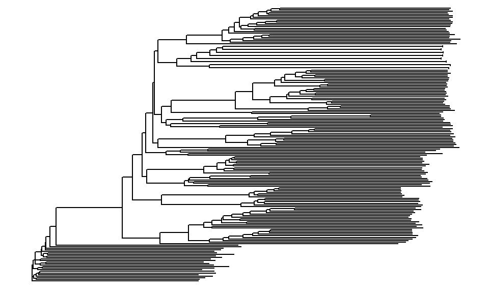

```r
library(ape)
library(ggtree)
OTU_tree<-nj(OTU_bin_dist)
ggtree(OTU_tree,layout="rectangular")
```

Note that this is **NOT A PHYLOGENY** – a phylogeny shows an hypothesis about evolutionary relationships among organisms. This is a neighbour-joining tree that clusters samples based on the similarity of their microbes.

To see if species cluster together, we can colour-code and annotate our tree using our `Samples` data.frame object.

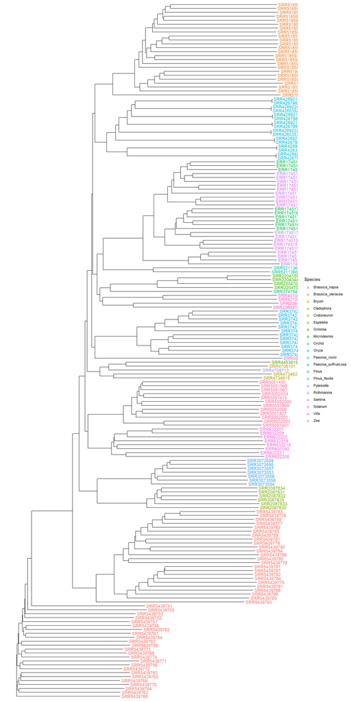

```r
ggtree(OTU_tree,layout="rectangular") %<+% Samples +
  geom_tiplab(aes(colour=Species)) +
  theme(legend.position="right")
```

## Bray-Curtis dissimilarity

In addition to binary distances, we can include abundance information. In our case ‘abundance’ is inferred from the number of sequence reads – the idea being that the more abundant a bacterial species is in the sample, the more likely it is for its DNA to be sequenced multiple times.

The `dist` function has other options for calculating distances:

```r
?dist
```

A popular measure is the [Bray-Curtis dissimilarity](https://en.wikipedia.org/wiki/Bray%E2%80%93Curtis_dissimilarity) metric. The Bray-Curtis dissimilarity (BC) between two samples $i$ and $j$ is:

$$BC_{ij} = 1-\frac{2 \sum_{k=1}^{N} min(Sp_{i,k},Sp_{j,k})}{\sum_{k=1}^{N} Sp_{i,k}+\sum_{k=1}^{N} Sp_{j,k}}$$
where $Sp_k$ is the number of ‘reads’ for the species k. Fortunately, the `vegan` package does this so we don’t have to calculate this manually.

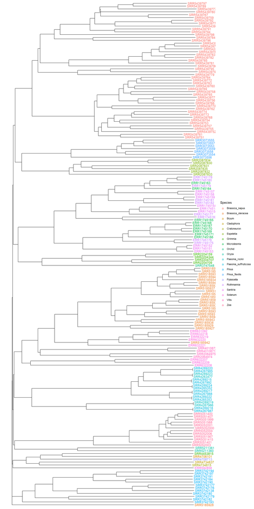

```r
library(vegan)
OTU_dist<- vegdist(OTUs,method="bray",binary=F)
OTU_tree2<-nj(OTU_dist)
ggtree(OTU_tree2,layout="rectangular") %<+% Samples +
  geom_tiplab(aes(colour=Species)) +
  theme(legend.position="right")
```

Notice the change in tree topology. Why?

## NMDS

In addition to tree-based clustering, we can use a Non-Metric Multidimensional Scaling (NMDS) to visualize similarity/differences among our samples. This method is a bit complicated, but you can see the [Wikipedia page](https://en.wikipedia.org/wiki/Multidimensional_scaling) for details. The important thing to know is that it is an algorithm for plotting points so that two points that are similar end up close together on the graph. Usually, this is done in two dimensions to generate a bivariate plot, but there are some cases where you might want just one or 3 or more.

```r
set.seed(13)
NMDSdat<-metaMDS(OTU_dist,k=2) # k = 2 dimensions
```

```
## *** No convergence -- monoMDS stopping criteria:
##     19: stress ratio > sratmax
##      1: scale factor of the gradient < sfgrmin
```

It looks like our model did not converge after 20 runs, we can try increasing this:

```r
set.seed(13)
NMDSdat<-metaMDS(OTU_dist,k=2,trymax = 100)
```

```
## *** No convergence -- monoMDS stopping criteria:
##      2: no. of iterations >= maxit
##     88: stress ratio > sratmax
##     10: scale factor of the gradient < sfgrmin
```

If it still hasn’t converged after 100 iterations, we can increase `trymax` to try to get a better solution. Go ahead and try and then compare to the figure below.

Create data for plotting:

```r
PDat<-data.frame(NMDS1=NMDSdat$points[,1],
                 NMDS2=NMDSdat$points[,2],
                 SampleID=row.names(OTUs))
```

Add species labels using the merge function:

```r
PDat<-merge(PDat,Samples,by="SampleID",all.x=T,all.y=F)
```

And plot:

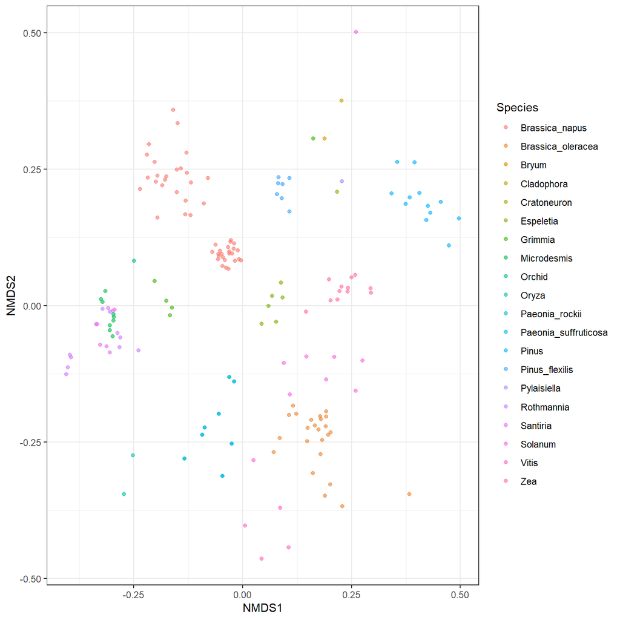

```r
qplot(x=NMDS1,y=NMDS2,colour=Species,alpha=I(0.6),data=PDat)+theme_bw()
```